# Project 2026 – Part 1: Explore, preprocess and quality-control the data

GSE80655 (Ramaker et al., 2017, Genome Medicine)

2026-11-19

# 0. Packages

```r
# CHANGED: installation lines commented out, otherwise everything is reinstalled at every Knit.
# Run them once in the console if a package is missing.
# install.packages(c("tidyverse", "pheatmap", "patchwork"))
# BiocManager::install(c("DESeq2", "edgeR", "limma", "EnsDb.Hsapiens.v75"))

library(tidyverse)
library(DESeq2)
library(edgeR)
library(limma)
library(pheatmap)
library(patchwork)

set.seed(2026)
dir.create("figures", showWarnings = FALSE)
```

# 1. Read the data

```r
# CHANGED: relative paths, so the script works on every computer.
# The two csv files must be in the same folder as this .Rmd file.
counts_raw <- read.csv("/Users/victoria/Documents/GitHub/Group 35/Data/GSE80655_counts.csv",   check.names = FALSE)
meta_raw   <- read.csv("/Users/victoria/Documents/GitHub/Group 35/Data/GSE80655_metadata.csv", check.names = FALSE,
                       stringsAsFactors = FALSE)

# Counts: first column = gene IDs, keep only numeric (sample) columns
gene_ids <- as.character(counts_raw[[1]])
is_num   <- vapply(counts_raw, is.numeric, logical(1))
counts   <- as.matrix(counts_raw[, is_num, drop = FALSE])
rownames(counts) <- make.unique(sub("\\..*$", "", gene_ids))  # drop ENSG version suffix

# If genes ended up as columns, transpose (genes should be rows)
if (nrow(counts) < ncol(counts)) counts <- t(counts)
```

# Q1. How many samples and features? What type is each variable?

```r
dim(counts)                       # paper: 57,905 genes x 281 samples
```

```
## [1] 57905   281
```

```r
dim(meta_raw)
```

```
## [1] 281  11
```

```r
str(meta_raw)
```

```
## 'data.frame':    281 obs. of  11 variables:
##  $ GSM         : chr  "GSM2132201" "GSM2132202" "GSM2132203" "GSM2132204" ...
##  $ title       : chr  "X1834_AnCg_C_SL31501" "X2315_AnCg_M_SL31502" "X2566_AnCg_B_SL31503" "X3031_AnCg_M_SL31504" ...
##  $ description : chr  "SL31501" "SL31502" "SL31503" "SL31504" ...
##  $ brain_region: chr  "AnCg" "AnCg" "AnCg" "AnCg" ...
##  $ diagnosis   : chr  "Control" "Major Depression" "Bipolar Disorder" "Major Depression" ...
##  $ age         : int  40 58 56 49 31 43 45 53 44 41 ...
##  $ sex         : chr  "M" "M" "F" "M" ...
##  $ ethnicity   : chr  "Caucasian" "Caucasian" "Caucasian" "Caucasian" ...
##  $ PMI         : num  12.2 24 29 27 22 ...
##  $ brain_pH    : num  6.76 6.93 6.83 7.19 6.77 7.1 6.86 6.78 6.87 7.01 ...
##  $ donor_id    : int  1834 2315 2566 3031 2353 2664 2805 2976 3196 3516 ...
```

```r
head(counts[, 1:5])
```

```
##                 SL31501 SL31502 SL31503 SL31504 SL31505
## ENSG00000223972       0       0       0       0       0
## ENSG00000227232      93      80     116      50     233
## ENSG00000243485       0       0       0       0       0
## ENSG00000237613       0       0       0       0       0
## ENSG00000268020       1       0       0       1       0
## ENSG00000240361       0       0       0       1       0
```

```r
# Are counts raw integers? (needed for DESeq2)
all(counts == round(counts))
```

```
## [1] TRUE
```

```r
range(counts)
```

```
## [1]       0 5831707
```

```r
# Find the metadata column whose values match the count-matrix column names
id_col <- names(meta_raw)[vapply(meta_raw,
            function(x) mean(colnames(counts) %in% as.character(x)) > 0.9,
            logical(1))][1]
id_col
```

```
## [1] "description"
```

```r
col_map <- c(sample    = id_col,
             region    = "brain_region",        # AnCg / DLPFC / nAcc
             diagnosis = "diagnosis",           # Control / Major Depression / Bipolar Disorder / Schizophrenia
             age       = "age",
             sex       = "sex",
             ph        = "brain_pH",
             pmi       = "PMI",
             race      = "ethnicity",
             donor     = "donor_id")            # subject ID

meta <- meta_raw %>% select(any_of(col_map))    # renames + drops missing ones

# Recode empty strings / text placeholders as real NAs
meta <- meta %>% mutate(across(where(is.character),
          ~ na_if(na_if(na_if(trimws(.x), ""), "NA"), "unknown")))

# Variable types
meta <- meta %>% mutate(
  region    = factor(region),
  diagnosis = factor(diagnosis),
  sex       = factor(sex),
  across(any_of(c("race", "donor")), factor),
  across(any_of(c("age", "ph", "pmi")), as.numeric))

meta$diagnosis <- relevel(meta$diagnosis,
                          ref = grep("ctl|control", levels(meta$diagnosis),
                                     ignore.case = TRUE, value = TRUE)[1])

# Align metadata rows with count columns
meta   <- meta[match(colnames(counts), meta$sample), ]
stopifnot(identical(meta$sample, colnames(counts)))
rownames(meta) <- meta$sample

# Overview tables
summary(meta)
```

```
##        sample      region              diagnosis       age        sex
##  Length   :281   AnCg :96   Control         :70   Min.   :19.00   F: 59
##  N.unique :281   DLPFC:94   Bipolar Disorder:71   1st Qu.:39.00   M:222
##  N.blank  :  0   nAcc :91   Major Depression:69   Median :48.00
##  Min.nchar:  6              Schizophrenia   :71   Mean   :46.74
##  Max.nchar:  7                                    3rd Qu.:55.00
##                                                   Max.   :72.00
##
##        ph             pmi                      race         donor
##  Min.   :6.520   Min.   : 6.25   African American:  6   1834   :  3
##  1st Qu.:6.770   1st Qu.:17.20   Asian           :  6   1881   :  3
##  Median :6.900   Median :24.00   Caucasian       :260   2208   :  3
##  Mean   :6.901   Mean   :22.67   Other           :  6   2267   :  3
##  3rd Qu.:7.037   3rd Qu.:27.50   Pacific Islander:  3   2292   :  3
##  Max.   :7.390   Max.   :44.25                          2311   :  3
##  NAs    :3                                              (Other):263
```

```r
table(meta$region, meta$diagnosis)
```

```
##
##         Control Bipolar Disorder Major Depression Schizophrenia
##   AnCg       24               24               24            24
##   DLPFC      24               23               23            24
##   nAcc       22               24               22            23
```

```r
table(meta$diagnosis, meta$sex)
```

```
##
##                     F  M
##   Control           8 62
##   Bipolar Disorder 24 47
##   Major Depression 18 51
##   Schizophrenia     9 62
```

```r
n_distinct(meta$donor)                 # paper: 96 donors
```

```
## [1] 96
```

```r
table(table(meta$donor))               # how many regions per donor
```

```
##
##  2  3
##  7 89
```

```r
# ADDED: one row per donor, used for all donor-level tests below
donors <- meta %>% distinct(donor, .keep_all = TRUE)
nrow(donors)
```

```
## [1] 96
```

**Interpretation.** The count matrix contains 57,905 genes × 281 samples of raw integer counts. Variable types: *diagnosis*, *region*, *sex*, *race* and *donor* are nominal; *age*, *pH* and *PMI* are continuous. There are 96 donors (24 per diagnosis) and most donors contributed tissue from all three regions, so **samples from the same donor are not independent**. Tests on donor-level variables are therefore done on one row per donor (`donors`), to avoid pseudoreplication.

# Q2. Missing values: where, why, and how to handle

```r
sum(is.na(counts))                       # expect 0
```

```
## [1] 0
```

```r
colSums(is.na(meta))
```

```
##    sample    region diagnosis       age       sex        ph       pmi      race
##         0         0         0         0         0         3         0         0
##     donor
##         0
```

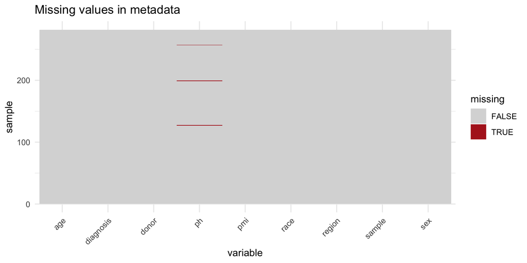

```r
# Visual map of missingness in the metadata
# CHANGED: plot stored in an object and printed, so it also appears in the HTML report
p_miss <- meta %>%
  mutate(across(everything(), is.na)) %>%
  rowid_to_column("row") %>%
  pivot_longer(-row, names_to = "variable", values_to = "missing") %>%
  ggplot(aes(variable, row, fill = missing)) +
  geom_tile() +
  scale_fill_manual(values = c(`FALSE` = "grey85", `TRUE` = "firebrick")) +
  labs(title = "Missing values in metadata", y = "sample") +
  theme_minimal() + theme(axis.text.x = element_text(angle = 45, hjust = 1))
print(p_miss)
```

```r
ggsave("figures/Q2_missingness.png", p_miss, width = 7, height = 5)
```

```r
# Which donor is missing pH?
meta %>% filter(is.na(ph)) %>% select(sample, donor, region, diagnosis)
```

```
##        sample donor region     diagnosis
## SL6616 SL6616  4463   AnCg Schizophrenia
## SL7390 SL7390  4463   nAcc Schizophrenia
## SL7802 SL7802  4463  DLPFC Schizophrenia
```

```r
# Is missingness related to diagnosis? (MCAR check)
# CHANGED: tested per donor instead of per sample (one donor = 3 samples otherwise)
for (v in c("age", "ph", "pmi")) if (v %in% names(donors) && any(is.na(donors[[v]]))) {
  print(v); print(table(missing = is.na(donors[[v]]), donors$diagnosis))
  print(fisher.test(table(is.na(donors[[v]]), donors$diagnosis)))
}
```

```
## [1] "ph"
##
## missing Control Bipolar Disorder Major Depression Schizophrenia
##   FALSE      24               24               24            23
##   TRUE        0                0                0             1
##
##  Fisher's Exact Test for Count Data
##
## data:  table(is.na(donors[[v]]), donors$diagnosis)
## p-value = 1
## alternative hypothesis: two.sided
```

```r
# "Structural" missingness: donors missing one or more brain regions
meta %>%
  dplyr::count(donor, region) %>%
  tidyr::complete(donor, region, fill = list(n = 0)) %>%
  dplyr::filter(n == 0) %>%
  dplyr::left_join(dplyr::distinct(meta, donor, diagnosis), by = "donor")
```

```
## # A tibble: 7 × 4
##   donor region     n diagnosis
##   <fct> <fct>  <int> <fct>
## 1 2248  nAcc       0 Control
## 2 2505  nAcc       0 Schizophrenia
## 3 2944  nAcc       0 Major Depression
## 4 3064  nAcc       0 Major Depression
## 5 3523  nAcc       0 Control
## 6 3755  DLPFC      0 Major Depression
## 7 3927  DLPFC      0 Bipolar Disorder
```

```r
# Handling: impute numeric covariates with the overall median (NOT per diagnosis,
# which would leak the outcome), and keep a flag so the choice is transparent.
# CHANGED: median computed over donors, so donors with 3 samples do not count 3 times
for (v in c("age", "ph", "pmi")) if (v %in% names(meta) && any(is.na(meta[[v]]))) {
  meta[[paste0(v, "_imputed")]] <- is.na(meta[[v]])
  meta[[v]][is.na(meta[[v]])]   <- median(donors[[v]], na.rm = TRUE)
}
donors <- meta %>% distinct(donor, .keep_all = TRUE)   # refresh with imputed values
```

**Interpretation.** The count matrix has no missing values. In the metadata only *brain pH* is missing, for one donor with schizophrenia (3 samples). With a single donor, missingness cannot be shown to depend on diagnosis, so we treat it as **MCAR** (missing completely at random). We impute the overall donor median rather than deleting the donor, because deletion reduces N and makes models with and without pH fit on different data. The flag `ph_imputed` keeps the choice visible. A few donors lack one brain region (structural missingness); this needs no imputation because analyses are done per region.

# Q3. Samples or features that behave unlike the rest

## 3a. Sample-level QC metrics

```r
# ADDED: mitochondrial genes (Ensembl IDs of the 37 chrM genes all start with ENSG000002 and
# are the last 37 rows of the matrix); a high mitochondrial fraction points to degraded tissue
mt_genes <- tail(rownames(counts), 37)

qc <- tibble(sample      = colnames(counts),
             lib_size    = colSums(counts),
             n_detected  = colSums(counts > 0),
             pct_top100  = apply(counts, 2, function(x)
                             sum(sort(x, decreasing = TRUE)[1:100]) / sum(x) * 100),
             pct_mito    = colSums(counts[mt_genes, ]) / colSums(counts) * 100) %>%   # ADDED
  left_join(meta, by = "sample")

summary(qc$lib_size)
```

```
##     Min.  1st Qu.   Median     Mean  3rd Qu.     Max.
## 11686051 33226797 40861958 42085354 50756429 73197862
```

```r
summary(qc$pct_mito)
```

```
##    Min. 1st Qu.  Median    Mean 3rd Qu.    Max.
##   8.529  12.929  15.839  17.922  20.455  59.263
```

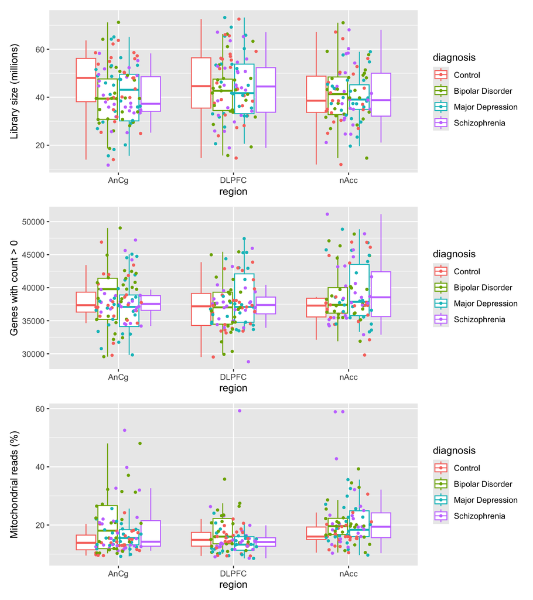

```r
p1 <- ggplot(qc, aes(region, lib_size / 1e6, colour = diagnosis)) +
  geom_boxplot(outlier.shape = NA) + geom_jitter(width = .2, size = 1) +
  labs(y = "Library size (millions)")
p2 <- ggplot(qc, aes(region, n_detected, colour = diagnosis)) +
  geom_boxplot(outlier.shape = NA) + geom_jitter(width = .2, size = 1) +
  labs(y = "Genes with count > 0")
p3 <- ggplot(qc, aes(region, pct_mito, colour = diagnosis)) +                         # ADDED
  geom_boxplot(outlier.shape = NA) + geom_jitter(width = .2, size = 1) +
  labs(y = "Mitochondrial reads (%)")
p_qc <- p1 / p2 / p3
print(p_qc)
```

```r
ggsave("figures/Q3_sample_qc.png", p_qc, width = 8, height = 9)

# Flag samples > 3 MAD from the median on log library size / detected genes
mad_out <- function(x) abs(x - median(x)) > 3 * mad(x)
qc <- qc %>% mutate(flag_libsize  = mad_out(log10(lib_size)),
                    flag_detected = mad_out(n_detected))
qc %>% filter(flag_libsize | flag_detected) %>%
  select(sample, region, diagnosis, lib_size, n_detected, pct_mito)
```

```
## # A tibble: 11 × 6
##    sample region diagnosis        lib_size n_detected pct_mito
##    <chr>  <fct>  <fct>               <dbl>      <dbl>    <dbl>
##  1 SL5881 nAcc   Control          11959298      29807     21.1
##  2 SL5882 nAcc   Bipolar Disorder 14620122      31896     20.1
##  3 SL5883 AnCg   Control          13980066      29775     13.8
##  4 SL5886 DLPFC  Control          14639561      29512     13.5
##  5 SL5890 AnCg   Major Depression 15584479      29828     11.8
##  6 SL6126 nAcc   Major Depression 44606321      48846     29.9
##  7 SL6346 AnCg   Schizophrenia    11686051      34590     22.0
##  8 SL6407 nAcc   Bipolar Disorder 32242689      48119     39.3
##  9 SL6414 AnCg   Bipolar Disorder 29194754      49036     48.0
## 10 SL6608 nAcc   Schizophrenia    60249887      51130     42.8
## 11 SL7857 nAcc   Schizophrenia    37315103      48160     58.9
```

```r
# Is library size associated with diagnosis? (technical vs biology)
kruskal.test(lib_size ~ diagnosis, data = qc)
```

```
##
##  Kruskal-Wallis rank sum test
##
## data:  lib_size by diagnosis
## Kruskal-Wallis chi-squared = 2.2233, df = 3, p-value = 0.5274
```

```r
kruskal.test(pct_mito ~ diagnosis, data = qc)                                          # ADDED
```

```
##
##  Kruskal-Wallis rank sum test
##
## data:  pct_mito by diagnosis
## Kruskal-Wallis chi-squared = 10.885, df = 3, p-value = 0.01236
```

```r
# ADDED: sample IDs (SLxxxx) seem to follow processing order; the SL58xx-SL60xx samples
# have much smaller libraries, which suggests a separate sequencing batch
qc <- qc %>% mutate(id_number = as.numeric(sub("SL", "", sample)),
                    id_series = cut(id_number, c(0, 6100, 9000, Inf),
                                    labels = c("SL58xx-SL60xx", "SL61xx-SL88xx", "SL3xxxx")))
qc %>% group_by(id_series) %>%
  summarise(n = n(), median_lib_M = median(lib_size) / 1e6)
```

```
## # A tibble: 3 × 3
##   id_series         n median_lib_M
##   <fct>         <int>        <dbl>
## 1 SL58xx-SL60xx    22         22.5
## 2 SL61xx-SL88xx   202         47.0
## 3 SL3xxxx          57         34.2
```

```r
table(qc$id_series, qc$diagnosis)
```

```
##
##                 Control Bipolar Disorder Major Depression Schizophrenia
##   SL58xx-SL60xx       8                5                4             5
##   SL61xx-SL88xx      46               53               50            53
##   SL3xxxx            16               13               15            13
```

**Interpretation.** Library size and mitochondrial fraction vary considerably between samples, so normalization is needed. Library size does not differ between diagnoses. Eleven samples are flagged by the 3-MAD rule. Most of them have either a very small library (the SL58xx–SL60xx samples, which look like a separate sequencing batch with lower depth) or an unusually high number of detected genes. That batch is spread over all four diagnoses, so it adds noise but is not confounded with diagnosis.

## 3b. Sex check

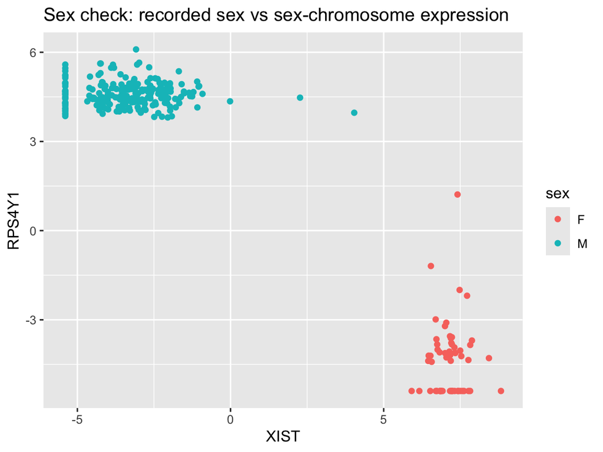

```r
sex_genes <- c(XIST = "ENSG00000229807", RPS4Y1 = "ENSG00000129824")
if (all(sex_genes %in% rownames(counts))) {
  cpm_all <- cpm(counts, log = TRUE, prior.count = 1)
  sexdf <- tibble(sample = colnames(counts),
                  XIST   = cpm_all[sex_genes["XIST"], ],
                  RPS4Y1 = cpm_all[sex_genes["RPS4Y1"], ]) %>% left_join(meta, by = "sample")
  # CHANGED: print() needed inside an if-block, otherwise the plot is not shown
  p_sex <- ggplot(sexdf, aes(XIST, RPS4Y1, colour = sex)) + geom_point() +
    labs(title = "Sex check: recorded sex vs sex-chromosome expression")
  print(p_sex)
  ggsave("figures/Q3_sex_check.png", p_sex, width = 6, height = 5)
}
```

## 3c. Sample–sample correlation

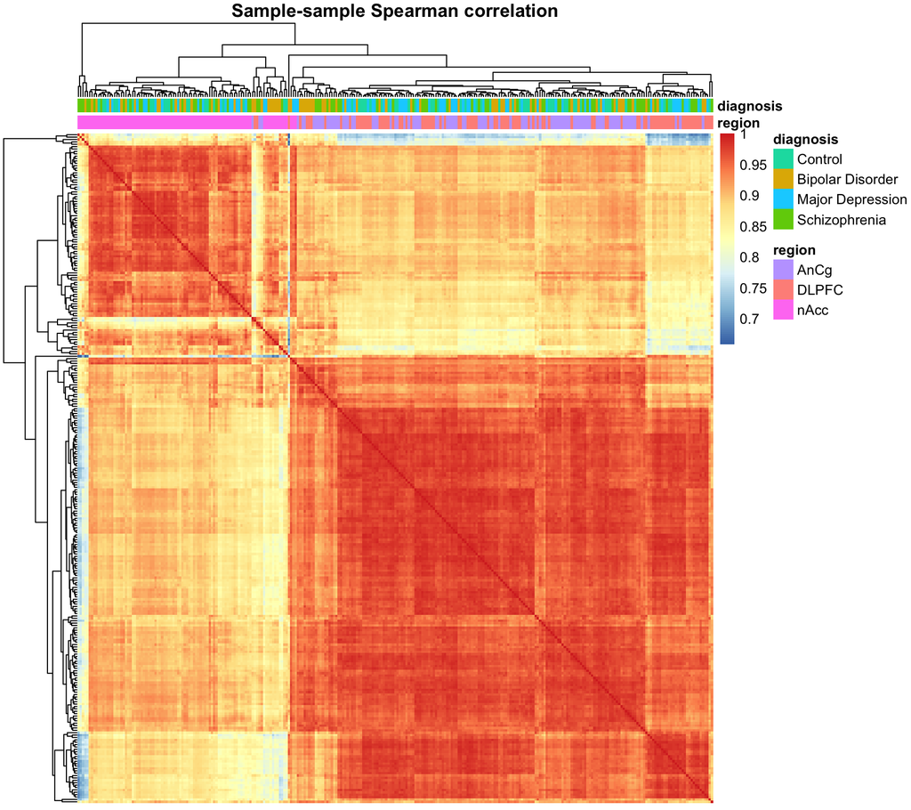

```r
logcpm_raw <- cpm(counts, log = TRUE, prior.count = 1)
keep_tmp   <- rowMeans(logcpm_raw) > 1
cor_mat    <- cor(logcpm_raw[keep_tmp, ], method = "spearman")
ann <- data.frame(region = meta$region, diagnosis = meta$diagnosis, row.names = meta$sample)

# CHANGED: heatmap drawn in the report and saved as a file
pheatmap(cor_mat, annotation_col = ann, show_rownames = FALSE, show_colnames = FALSE,
         main = "Sample-sample Spearman correlation")
```

```r
pheatmap(cor_mat, annotation_col = ann, show_rownames = FALSE, show_colnames = FALSE,
         main = "Sample-sample Spearman correlation",
         filename = "figures/Q3_cor_heatmap.png", width = 9, height = 8)

# CHANGED: median correlation computed WITHIN each region. Across all regions, nAcc samples
# always look less similar simply because nAcc differs from cortex.
qc$median_cor <- NA_real_
for (r in levels(meta$region)) {
  idx <- which(meta$region == r)
  sub <- cor_mat[idx, idx]
  qc$median_cor[idx] <- apply(sub, 1, function(x) median(x[x < 1]))
}
qc <- qc %>% group_by(region) %>%
  mutate(flag_cor = median_cor < quantile(median_cor, .25) - 1.5 * IQR(median_cor)) %>%   # IQR rule
  ungroup()
qc %>% filter(flag_cor) %>% arrange(donor) %>%
  select(sample, donor, region, diagnosis, median_cor, pct_mito, ph)
```

```
## # A tibble: 30 × 7
##    sample donor region diagnosis        median_cor pct_mito    ph
##    <chr>  <fct> <fct>  <fct>                 <dbl>    <dbl> <dbl>
##  1 SL6605 1834  nAcc   Control               0.894    15.3   6.76
##  2 SL7391 2315  nAcc   Major Depression      0.901    16.3   6.93
##  3 SL7843 2384  nAcc   Schizophrenia         0.848    23.4   6.81
##  4 SL6659 2505  AnCg   Schizophrenia         0.936    11.5   6.83
##  5 SL7844 2505  DLPFC  Schizophrenia         0.919    12.6   6.83
##  6 SL7159 3451  AnCg   Bipolar Disorder      0.941    31.3   6.87
##  7 SL6407 3452  nAcc   Bipolar Disorder      0.877    39.3   6.65
##  8 SL6414 3452  AnCg   Bipolar Disorder      0.866    48.0   6.65
##  9 SL7701 3452  DLPFC  Bipolar Disorder      0.852    35.8   6.65
## 10 SL6412 3572  DLPFC  Control               0.916     9.39  6.68
## # ℹ 20 more rows
```

**Interpretation.** Samples cluster first by region. Within each region, 30 samples fall below the IQR threshold (Q1 − 1.5 × IQR) of within-region correlation. Most of them come from patient groups (14 schizophrenia, 12 bipolar disorder, 2 depression, 2 controls), several donors are flagged in two or three regions (e.g. donors 3452, 4242 and 4404 in all three), and their mitochondrial fraction is clearly higher (median 27 % versus 16 % overall). This points to donor-level tissue quality (for example the circumstances of death) rather than a technical error in one sample.

## 3d. Feature-level behaviour

```r
gene_stats <- tibble(gene      = rownames(counts),
                     total     = rowSums(counts),
                     pct_zero  = rowMeans(counts == 0) * 100)
sum(gene_stats$total == 0)                      # genes never detected
```

```
## [1] 1985
```

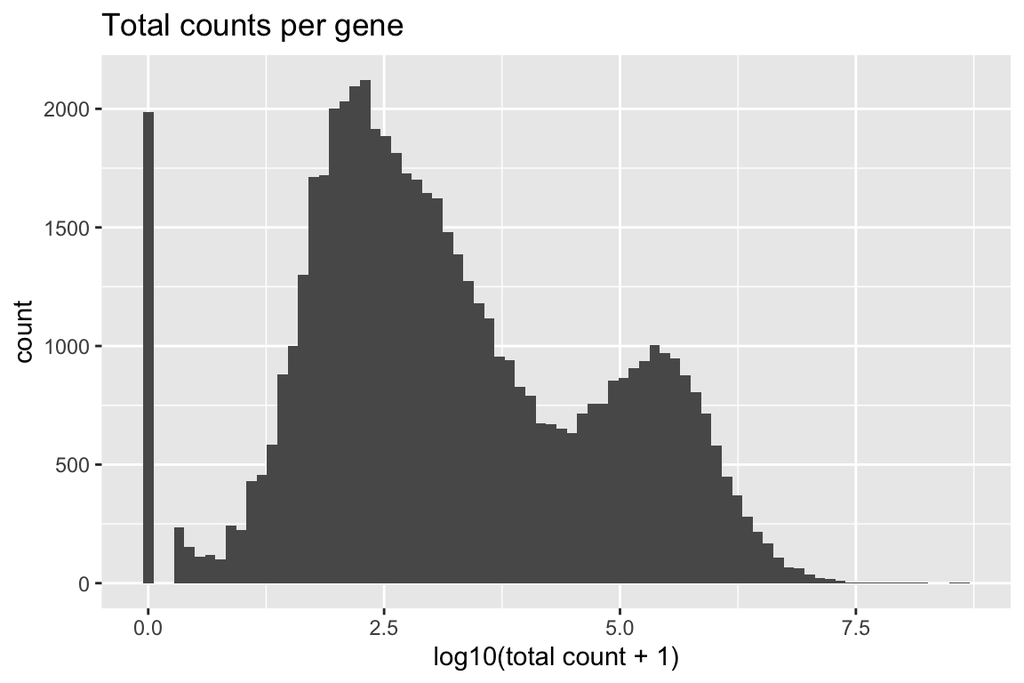

```r
p_gt <- ggplot(gene_stats, aes(log10(total + 1))) + geom_histogram(bins = 80) +
  labs(title = "Total counts per gene", x = "log10(total count + 1)")
print(p_gt)
```

```r
ggsave("figures/Q3_gene_totals.png", p_gt, width = 6, height = 4)
gene_stats %>% arrange(desc(total)) %>% head(20)  # dominating genes (MT-, rRNA?)
```

```
## # A tibble: 20 × 3
##    gene                total pct_zero
##    <chr>               <dbl>    <dbl>
##  1 ENSG00000198804 448002959        0
##  2 ENSG00000198886 392634186        0
##  3 ENSG00000210082 374669642        0
##  4 ENSG00000198727 149850869        0
##  5 ENSG00000198888 138688020        0
##  6 ENSG00000198786 122947767        0
##  7 ENSG00000198763 116917584        0
##  8 ENSG00000198712  95779883        0
##  9 ENSG00000198938  72070907        0
## 10 ENSG00000198899  71812306        0
## 11 ENSG00000211459  56152151        0
## 12 ENSG00000197971  53433634        0
## 13 ENSG00000251562  46911703        0
## 14 ENSG00000131711  42289809        0
## 15 ENSG00000131095  42031493        0
## 16 ENSG00000130294  37017766        0
## 17 ENSG00000166963  34917989        0
## 18 ENSG00000266658  34182970        0
## 19 ENSG00000198668  32526721        0
## 20 ENSG00000120885  29965591        0
```

# Q4. Pre-processing: annotation, filtering, normalization, transformation

## 4a. Remove X/Y-chromosome genes

```r
if (requireNamespace("EnsDb.Hsapiens.v75", quietly = TRUE)) {   # = GRCh37 E75, as in paper
  gi  <- ensembldb::genes(EnsDb.Hsapiens.v75::EnsDb.Hsapiens.v75)
  chr <- as.character(GenomicRanges::seqnames(gi))[match(rownames(counts), gi$gene_id)]
  print(table(chr %in% c("X", "Y")))
  counts_auto <- counts[!(chr %in% c("X", "Y")), ]
} else {
  # CHANGED: warn instead of silently skipping this step
  message("EnsDb.Hsapiens.v75 not installed: X/Y genes were NOT removed")
  counts_auto <- counts
}
```

```
##
## FALSE  TRUE
## 55018  2887
```

```r
dim(counts_auto)
```

```
## [1] 55018   281
```

## 4b. Outlier samples

```r
# Decision: no samples are removed (see interpretation below).
drop_samples <- character(0)
counts_qc <- counts_auto[, !colnames(counts_auto) %in% drop_samples]
meta_qc   <- droplevels(meta[colnames(counts_qc), ])
```

**Decision.** We keep all samples. The flagged samples come mainly from patient groups and cluster by donor, so removing them could bias the patient groups towards the “best-preserved” brains. Their technical variation is handled instead by including quality covariates (pH, RNA quality) in the models of Parts 2–4. A sensitivity analysis without these donors can show whether conclusions depend on them.

## 4c. Filtering

```r
# Filter lowly expressed genes (edgeR::filterByExpr, grouped by region x diagnosis)
# ADDED NOTE: this filter uses the group labels. That is fine for exploration, but Part 3
# requires a filter that does NOT depend on the labels (e.g. CPM >= 1 in >= 10 samples).
grp  <- interaction(meta_qc$region, meta_qc$diagnosis)
keep <- filterByExpr(counts_qc, group = grp, min.count = 10)
table(keep)
```

```
## keep
## FALSE  TRUE
## 29081 25937
```

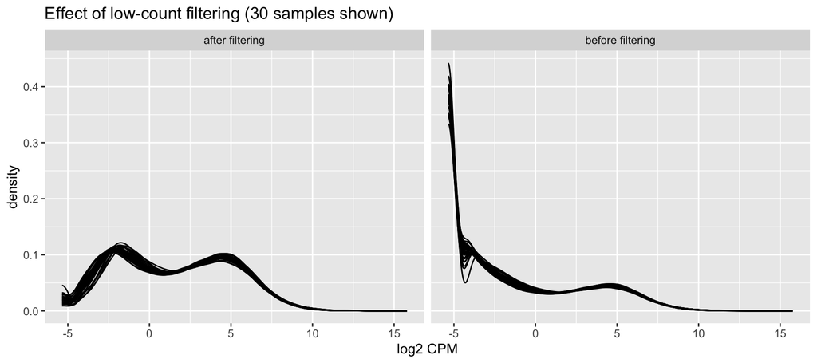

```r
counts_f <- counts_qc[keep, ]

# Before/after density plot of log-CPM
dens <- function(m, lab) as_tibble(cpm(m, log = TRUE, prior.count = 1)[, 1:30]) %>%
  pivot_longer(everything()) %>% mutate(step = lab)
p_filt <- bind_rows(dens(counts_qc, "before filtering"), dens(counts_f, "after filtering")) %>%
  ggplot(aes(value, group = name)) + geom_density(alpha = .3) + facet_wrap(~step) +
  labs(x = "log2 CPM", title = "Effect of low-count filtering (30 samples shown)")
print(p_filt)
```

```r
ggsave("figures/Q4_filtering.png", p_filt, width = 9, height = 4)
```

## 4d. Normalization and transformation

```r
# Normalization (DESeq2 median-of-ratios) + variance-stabilizing transform
dds <- DESeqDataSetFromMatrix(countData = round(counts_f), colData = meta_qc,
                              design = ~ region + diagnosis)
dds <- estimateSizeFactors(dds)
summary(sizeFactors(dds))
```

```
##    Min. 1st Qu.  Median    Mean 3rd Qu.    Max.
##  0.2588  0.8334  1.0613  1.0648  1.3127  1.8356
```

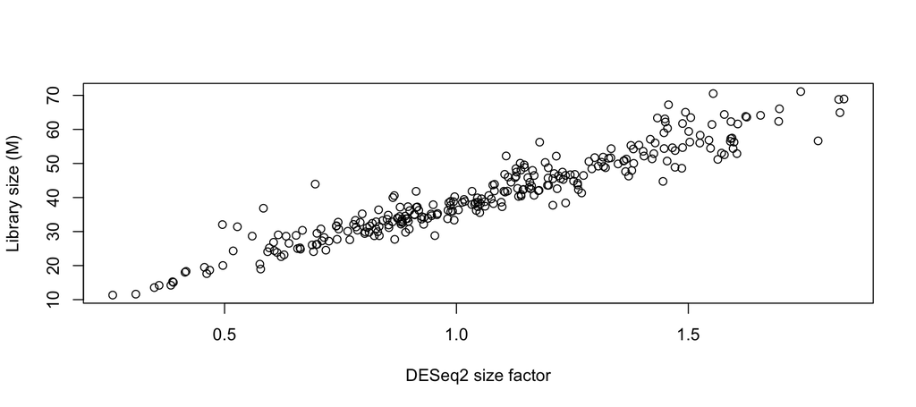

```r
plot(sizeFactors(dds), colSums(counts_f) / 1e6,
     xlab = "DESeq2 size factor", ylab = "Library size (M)")
```

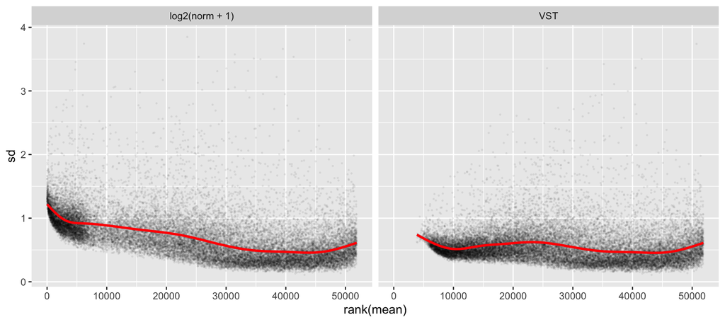

```r
vsd <- vst(dds, blind = TRUE)          # blind = TRUE: unbiased by design for QC
vmat <- assay(vsd)

# Mean-variance before/after transformation
raw_norm <- counts(dds, normalized = TRUE)
mv <- bind_rows(
  tibble(mean = rowMeans(log2(raw_norm + 1)), sd = rowSds(log2(raw_norm + 1)), data = "log2(norm + 1)"),
  tibble(mean = rowMeans(vmat), sd = rowSds(vmat), data = "VST"))
p_mv <- ggplot(mv, aes(rank(mean), sd)) + geom_point(alpha = .05, size = .3) +
  geom_smooth(colour = "red") + facet_wrap(~data) + labs(x = "rank(mean)")
print(p_mv)
```

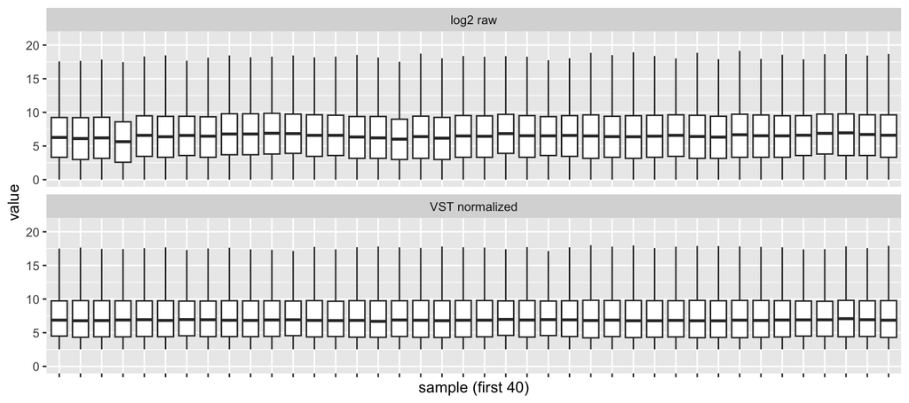

```r
ggsave("figures/Q4_mean_sd.png", p_mv, width = 9, height = 4)

# Boxplots of samples: raw vs normalized + transformed
p_box <- bind_rows(
  as_tibble(log2(counts_f[, 1:40] + 1)) %>% pivot_longer(everything()) %>% mutate(step = "log2 raw"),
  as_tibble(vmat[, 1:40]) %>% pivot_longer(everything()) %>% mutate(step = "VST normalized")) %>%
  ggplot(aes(name, value)) + geom_boxplot(outlier.shape = NA) + facet_wrap(~step, ncol = 1) +
  theme(axis.text.x = element_blank()) + labs(x = "sample (first 40)")
print(p_box)
```

```r
ggsave("figures/Q4_boxplots.png", p_box, width = 9, height = 6)
```

**Interpretation.** Filtering removes genes that are (almost) never detected; they carry no information and every extra gene is an extra test later on. Size factors correct for differences in sequencing depth. After VST, the standard deviation no longer depends on the mean expression, which is what PCA and clustering assume, and the sample distributions become comparable.

# Q5. Do samples cluster by biology or by a technical factor?

```r
run_pca <- function(mat, md, ntop = 500) {
  sel <- head(order(rowVars(mat), decreasing = TRUE), ntop)
  pc  <- prcomp(t(mat[sel, ]))
  list(pc = pc, var = round(100 * pc$sdev^2 / sum(pc$sdev^2), 1),
       df = bind_cols(md, as_tibble(pc$x[, 1:10])))
}
```

## 5a. All samples

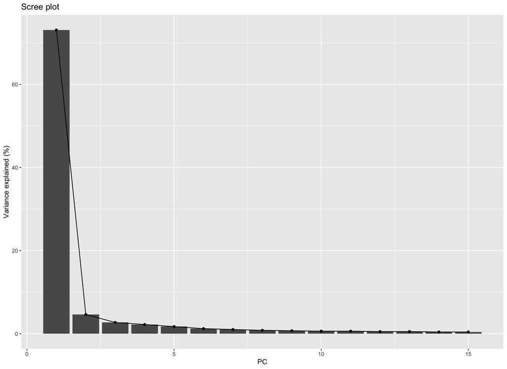

```r
pca_all <- run_pca(vmat, meta_qc %>% left_join(select(qc, sample, lib_size, n_detected, pct_mito), by = "sample"))

# ADDED: scree plot, to judge how many PCs are worth interpreting
p_scree <- tibble(PC = 1:15, var = pca_all$var[1:15]) %>%
  ggplot(aes(PC, var)) + geom_col() + geom_line() + geom_point() +
  labs(y = "Variance explained (%)", title = "Scree plot")

pa <- ggplot(pca_all$df, aes(PC1, PC2, colour = region)) + geom_point() +
  labs(x = paste0("PC1 (", pca_all$var[1], "%)"), y = paste0("PC2 (", pca_all$var[2], "%)"))
pb <- ggplot(pca_all$df, aes(PC1, PC2, colour = diagnosis)) + geom_point()
pc_ <- ggplot(pca_all$df, aes(PC1, PC2, colour = log10(lib_size))) + geom_point() +
  scale_colour_viridis_c()
pd <- ggplot(pca_all$df, aes(PC1, PC2, colour = sex)) + geom_point()
p_pca <- (pa | pb) / (pc_ | pd)
print(p_scree)
```

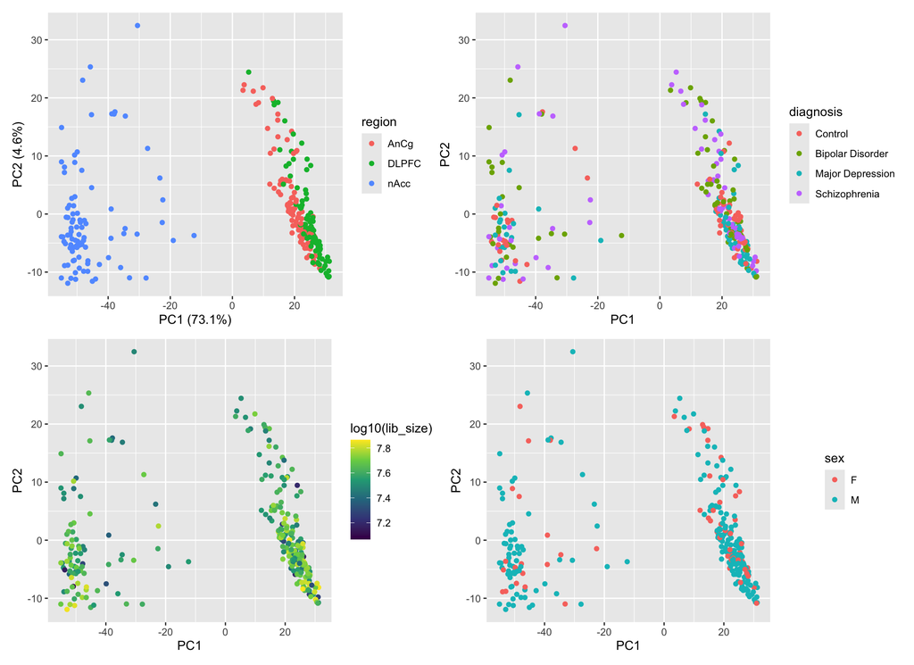

```r
print(p_pca)
```

```r
ggsave("figures/Q5_pca_all.png", p_pca, width = 11, height = 8)
```

## 5b. Association of top PCs with every covariate

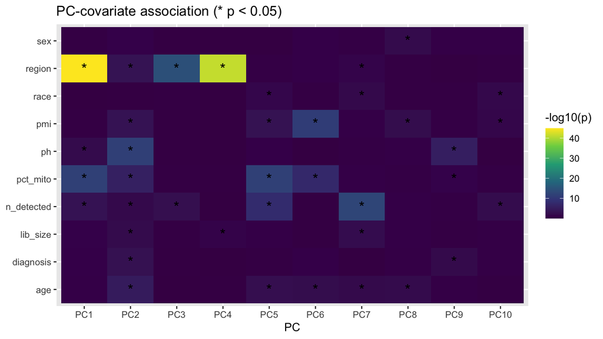

```r
covs <- intersect(c("region", "diagnosis", "sex", "race", "age", "ph", "pmi",
                    "lib_size", "n_detected", "pct_mito"), names(pca_all$df))      # CHANGED: + pct_mito
assoc <- expand_grid(PC = paste0("PC", 1:10), cov = covs) %>%
  rowwise() %>%
  mutate(p = {
    x <- pca_all$df[[cov]]; y <- pca_all$df[[PC]]
    if (is.numeric(x)) cor.test(x, y, method = "spearman", exact = FALSE)$p.value
    else kruskal.test(y ~ factor(x))$p.value
  }) %>% ungroup() %>% mutate(PC = factor(PC, paste0("PC", 1:10)))
p_assoc <- ggplot(assoc, aes(PC, cov, fill = -log10(p))) + geom_tile() +
  geom_text(aes(label = ifelse(p < 0.05, "*", "")), size = 5) +
  scale_fill_viridis_c() + labs(title = "PC-covariate association (* p < 0.05)", y = NULL)
print(p_assoc)
```

```r
ggsave("figures/Q5_pc_covariate_assoc.png", p_assoc, width = 8, height = 4.5)
```

## 5c. Within each region

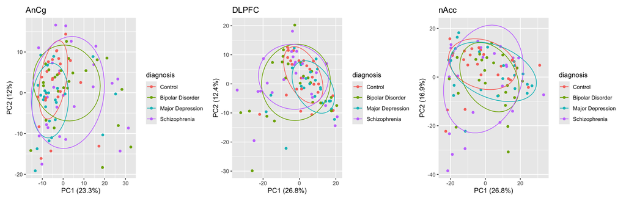

```r
plots <- lapply(levels(meta_qc$region), function(r) {
  idx <- meta_qc$region == r
  p   <- run_pca(vmat[, idx], meta_qc[idx, ])
  ggplot(p$df, aes(PC1, PC2, colour = diagnosis)) + geom_point() +
    stat_ellipse(level = .68) +
    labs(title = r, x = paste0("PC1 (", p$var[1], "%)"), y = paste0("PC2 (", p$var[2], "%)"))
})
p_reg <- wrap_plots(plots, ncol = 3)
print(p_reg)
```

```r
ggsave("figures/Q5_pca_by_region.png", p_reg, width = 14, height = 4.5)
```

## 5d. Hierarchical clustering

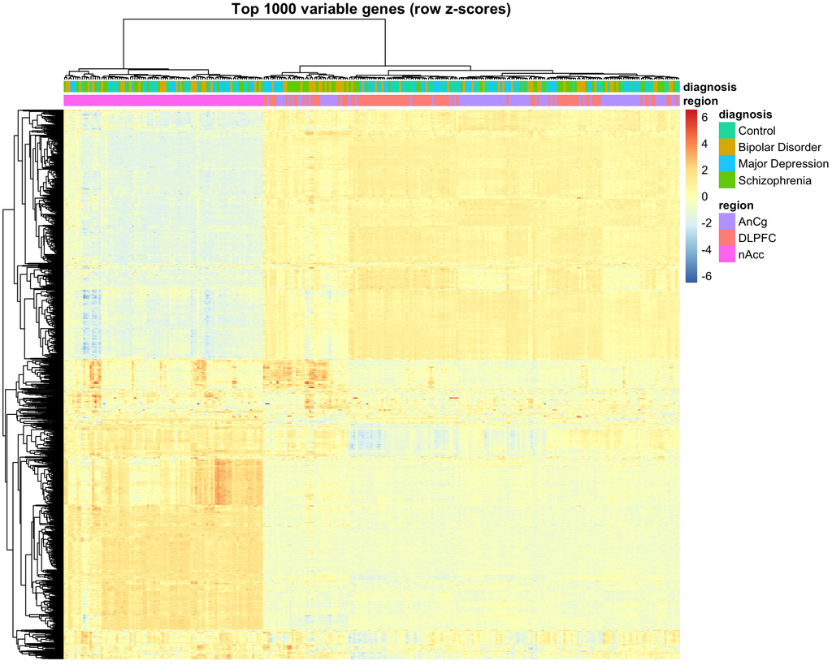

```r
# Ward linkage on Euclidean distance, as in the paper
sel <- head(order(rowVars(vmat), decreasing = TRUE), 1000)
hc  <- hclust(dist(t(vmat[sel, ])), method = "ward.D2")
pheatmap(vmat[sel, ], scale = "row", cluster_cols = hc, annotation_col = ann[colnames(vmat), ],
         show_rownames = FALSE, show_colnames = FALSE,
         main = "Top 1000 variable genes (row z-scores)")
```

```r
pheatmap(vmat[sel, ], scale = "row", cluster_cols = hc, annotation_col = ann[colnames(vmat), ],
         show_rownames = FALSE, show_colnames = FALSE,
         main = "Top 1000 variable genes (row z-scores)",
         filename = "figures/Q5_heatmap_clusters.png", width = 10, height = 8)
table(cluster = cutree(hc, k = 3), region = meta_qc$region)
```

```
##        region
## cluster AnCg DLPFC nAcc
##       1   76    75    0
##       2    0     0   91
##       3   20    19    0
```

## 5e. Visualisation-only correction for technical covariates

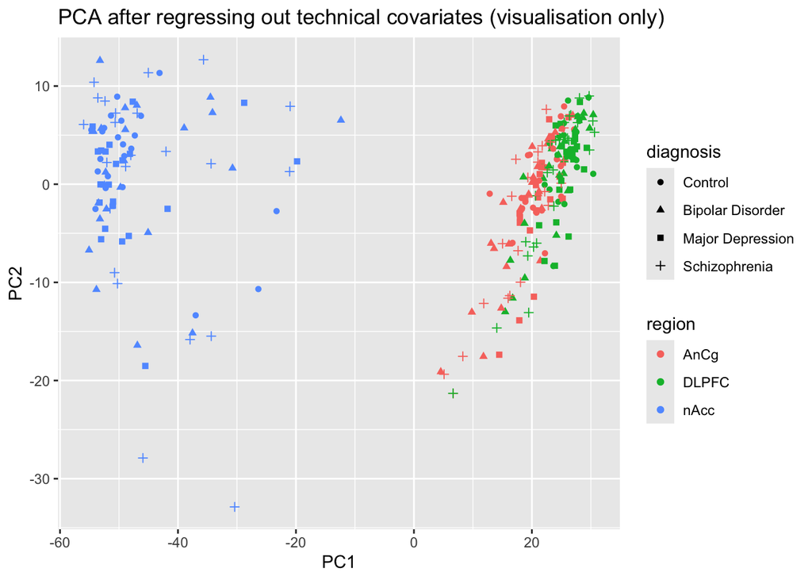

```r
# (Never feed these corrected values into DESeq2 — covariates go in the design.)
tech <- model.matrix(~ scale(log(colSums(counts_f))) + ph + pmi + age, data = meta_qc)[, -1]
vmat_corr <- removeBatchEffect(vmat, covariates = tech,
                               design = model.matrix(~ region + diagnosis, meta_qc))
pca_corr <- run_pca(vmat_corr, meta_qc)
p_corr <- ggplot(pca_corr$df, aes(PC1, PC2, colour = region, shape = diagnosis)) + geom_point() +
  labs(title = "PCA after regressing out technical covariates (visualisation only)")
print(p_corr)
```

```r
ggsave("figures/Q5_pca_corrected.png", p_corr, width = 7, height = 5)
```

# Q6. Is the preprocessed dataset suitable for the next parts?

```r
# Design balance per region (power) and confounding of covariates with diagnosis
table(meta_qc$region, meta_qc$diagnosis)
```

```
##
##         Control Bipolar Disorder Major Depression Schizophrenia
##   AnCg       24               24               24            24
##   DLPFC      24               23               23            24
##   nAcc       22               24               22            23
```

```r
# CHANGED: tests per donor instead of per sample, to avoid pseudoreplication.
# (Per sample, sex vs diagnosis gives p ~ 0.002; per donor it is not significant.)
donors_qc <- meta_qc %>% distinct(donor, .keep_all = TRUE)
for (v in intersect(c("age", "ph", "pmi"), names(donors_qc)))
  print(c(v, signif(kruskal.test(donors_qc[[v]] ~ donors_qc$diagnosis)$p.value, 3)))
```

```
## [1] "age"   "0.184"
## [1] "ph"       "2.39e-05"
## [1] "pmi"   "0.128"
```

```r
fisher.test(table(donors_qc$diagnosis, donors_qc$sex))
```

```
##
##  Fisher's Exact Test for Count Data
##
## data:  table(donors_qc$diagnosis, donors_qc$sex)
## p-value = 0.2468
## alternative hypothesis: two.sided
```

```r
# Save the analysis-ready objects
saveRDS(list(counts = counts_f, meta = meta_qc, qc = qc, dds = dds, vsd = vsd),
        "GSE80655_preprocessed.rds")
```

**Conclusion of Part 1.** The data are suitable for the next parts, with three consequences:

1. **Analyse per region.** Region dominates the variation, and within one region every donor occurs only once, which avoids pseudoreplication.
2. **Adjust for brain pH and RNA quality.** pH differs between diagnosis groups and, together with the mitochondrial fraction, drives the main technical PCs.
3. **Expect small effects.** Diagnosis does not drive any major PC, so effects per gene will be small and multiple-testing correction will be strict.